# Chronic Kidney disease dataset

Bakki Akhil

# Here we are analysing the Chronic kidney disease dataset

# The problem statement in this dataset is

## Estimating the relationship of blood pressure on other independent variables like age, blood Urea, Potassium, sodium, serum creatinine, hemoglobin, blood glucose random finding their effect in changing the blood pressure

# Here we are performing Multiple linear regression on the dataset

# The dependent variable for this dataset is blood pressure and the independent variables are age, blood Urea, Potassium, sodium, serum creatinine, hemoglobin, blood glucose random

# Below we are uploading the dataset

```r
data1 = read.csv("D:\\Akhil MBA\\MBA 4 Trimester\\Machine Learning Programming Using R\\CIA 1\\kidney_disease.csv", stringsAsFactors = TRUE)
View(data1)
str(data1)
```

```
## 'data.frame':    400 obs. of  26 variables:
##  $ id            : int  0 1 2 3 4 5 6 7 8 9 ...
##  $ age           : int  48 7 62 48 51 60 68 24 52 53 ...
##  $ bp            : int  80 50 80 70 80 90 70 NA 100 90 ...
##  $ sg            : num  1.02 1.02 1.01 1 1.01 ...
##  $ al            : int  1 4 2 4 2 3 0 2 3 2 ...
##  $ su            : int  0 0 3 0 0 0 0 4 0 0 ...
##  $ rbc           : Factor w/ 2 levels "abnormal","normal": 2 1 2 2 2 1 1 1 2 2 ...
##  $ pc            : Factor w/ 2 levels "abnormal","normal": 1 2 2 1 2 1 2 1 1 1 ...
##  $ pcc           : Factor w/ 2 levels "notpresent","present": 1 1 1 2 1 1 1 1 2 2 ...
##  $ ba            : Factor w/ 2 levels "notpresent","present": 1 1 1 1 1 1 1 1 1 1 ...
##  $ bgr           : int  121 NA 423 117 106 74 100 410 138 70 ...
##  $ bu            : num  36 18 53 56 26 25 54 31 60 107 ...
##  $ sc            : num  1.2 0.8 1.8 3.8 1.4 1.1 24 1.1 1.9 7.2 ...
##  $ sod           : num  NA NA NA 111 NA 142 104 NA NA 114 ...
##  $ pot           : num  NA NA NA 2.5 NA 3.2 4 NA NA 3.7 ...
##  $ hemo          : num  15.4 11.3 9.6 11.2 11.6 12.2 12.4 12.4 10.8 9.5 ...
##  $ pcv           : int  44 38 31 32 35 39 36 44 33 29 ...
##  $ wc            : int  7800 6000 7500 6700 7300 7800 25 6900 9600 12100 ...
##  $ rc            : num  5.2 2.5 2.5 3.9 4.6 4.4 2.5 5 4 3.7 ...
##  $ htn           : Factor w/ 2 levels "no","yes": 2 1 1 2 1 2 1 1 2 2 ...
##  $ dm            : Factor w/ 5 levels " yes","\tno",..: 5 4 5 4 4 5 4 5 5 5 ...
##  $ cad           : Factor w/ 3 levels "\tno","no","yes": 2 2 2 2 2 2 2 2 2 2 ...
##  $ appet         : Factor w/ 2 levels "good","poor": 1 1 2 2 1 1 1 1 1 2 ...
##  $ pe            : Factor w/ 3 levels "no","no ","yes": 1 1 1 3 1 3 1 3 1 1 ...
##  $ ane           : Factor w/ 2 levels "no","yes": 1 1 2 2 1 1 1 1 2 2 ...
##  $ classification: int  1 1 1 1 1 1 1 1 1 1 ...
```

```r
summary(data1)
```

```
##        id              age              bp               sg
##  Min.   :  0.00   Min.   : 2.00   Min.   : 50.00   Min.   :1.005
##  1st Qu.: 99.75   1st Qu.:42.00   1st Qu.: 70.00   1st Qu.:1.010
##  Median :199.50   Median :55.00   Median : 80.00   Median :1.020
##  Mean   :199.50   Mean   :51.48   Mean   : 76.47   Mean   :1.017
##  3rd Qu.:299.25   3rd Qu.:64.50   3rd Qu.: 80.00   3rd Qu.:1.020
##  Max.   :399.00   Max.   :90.00   Max.   :180.00   Max.   :1.025
##                   NA's   :9       NA's   :12       NA's   :47
##        al              su               rbc             pc
##  Min.   :0.000   Min.   :0.0000   abnormal:189   abnormal:195
##  1st Qu.:0.000   1st Qu.:0.0000   normal  :211   normal  :205
##  Median :0.000   Median :0.0000
##  Mean   :1.017   Mean   :0.4501
##  3rd Qu.:2.000   3rd Qu.:0.0000
##  Max.   :5.000   Max.   :5.0000
##  NA's   :46      NA's   :49
##          pcc               ba           bgr            bu
##  notpresent:354   notpresent:374   Min.   : 22   Min.   :  1.50
##  present   : 46   present   : 26   1st Qu.: 99   1st Qu.: 27.00
##                                    Median :121   Median : 42.00
##                                    Mean   :148   Mean   : 57.43
##                                    3rd Qu.:163   3rd Qu.: 66.00
##                                    Max.   :490   Max.   :391.00
##                                    NA's   :44    NA's   :19
##        sc              sod             pot              hemo
##  Min.   : 0.400   Min.   :  4.5   Min.   : 2.500   Min.   : 3.10
##  1st Qu.: 0.900   1st Qu.:135.0   1st Qu.: 3.800   1st Qu.:10.30
##  Median : 1.300   Median :138.0   Median : 4.400   Median :12.65
##  Mean   : 3.072   Mean   :137.5   Mean   : 4.627   Mean   :12.53
##  3rd Qu.: 2.800   3rd Qu.:142.0   3rd Qu.: 4.900   3rd Qu.:15.00
##  Max.   :76.000   Max.   :163.0   Max.   :47.000   Max.   :17.80
##  NA's   :17       NA's   :87      NA's   :88       NA's   :52
##       pcv              wc              rc         htn         dm       cad
##  Min.   : 9.00   Min.   :   13   Min.   :2.100   no :253    yes:  1   \tno:  2
##  1st Qu.:27.00   1st Qu.:   51   1st Qu.:2.500   yes:147   \tno :  3   no :364
##  Median :37.00   Median : 6900   Median :4.000             \tyes:  2   yes: 34
##  Mean   :36.58   Mean   : 6191   Mean   :3.985             no  :260
##  3rd Qu.:44.00   3rd Qu.: 9400   3rd Qu.:5.100             yes :134
##  Max.   :54.00   Max.   :26400   Max.   :8.000
##
##   appet       pe       ane      classification
##  good:318   no :323   no :340   Min.   :0.000
##  poor: 82   no :  1   yes: 60   1st Qu.:0.000
##             yes: 76             Median :1.000
##                                 Mean   :0.625
##                                 3rd Qu.:1.000
##                                 Max.   :1.000
##
```

# Checking the presence of null values in whole dataset

# The below code says there are 470 null values

```r
sum(is.na(data1))
```

```
## [1] 470
```

# Before analysing the data we are checking the presence of missing values in the varaibles

# Finding the null values in each dataset

```r
sapply(data1, function(x) sum(is.na(x)))
```

```
##             id            age             bp             sg             al
##              0              9             12             47             46
##             su            rbc             pc            pcc             ba
##             49              0              0              0              0
##            bgr             bu             sc            sod            pot
##             44             19             17             87             88
##           hemo            pcv             wc             rc            htn
##             52              0              0              0              0
##             dm            cad          appet             pe            ane
##              0              0              0              0              0
## classification
##              0
```

# Replacing thes null values with their means for better operation

```r
data1$age[which(is.na(data1$age))] = mean(data1$age, na.rm = TRUE)
data1$bp[which(is.na(data1$bp))] = mean(data1$bp, na.rm = TRUE)
data1$bu[which(is.na(data1$bu))] = mean(data1$bu, na.rm = TRUE)
data1$sc[which(is.na(data1$sc))] = mean(data1$sc, na.rm = TRUE)
data1$su[which(is.na(data1$su))] = mean(data1$su, na.rm = TRUE)
data1$hemo[which(is.na(data1$hemo))] = mean(data1$hemo, na.rm = TRUE)
data1$sg[which(is.na(data1$sg))] = mean(data1$sg, na.rm = TRUE)
data1$al[which(is.na(data1$al))] = mean(data1$al, na.rm = TRUE)
data1$bgr[which(is.na(data1$bgr))] = mean(data1$bgr, na.rm = TRUE)
data1$sod[which(is.na(data1$sod))] = mean(data1$sod, na.rm = TRUE)
data1$pot[which(is.na(data1$pot))] = mean(data1$pot, na.rm = TRUE)
```

# Checking the presence of null values graphically

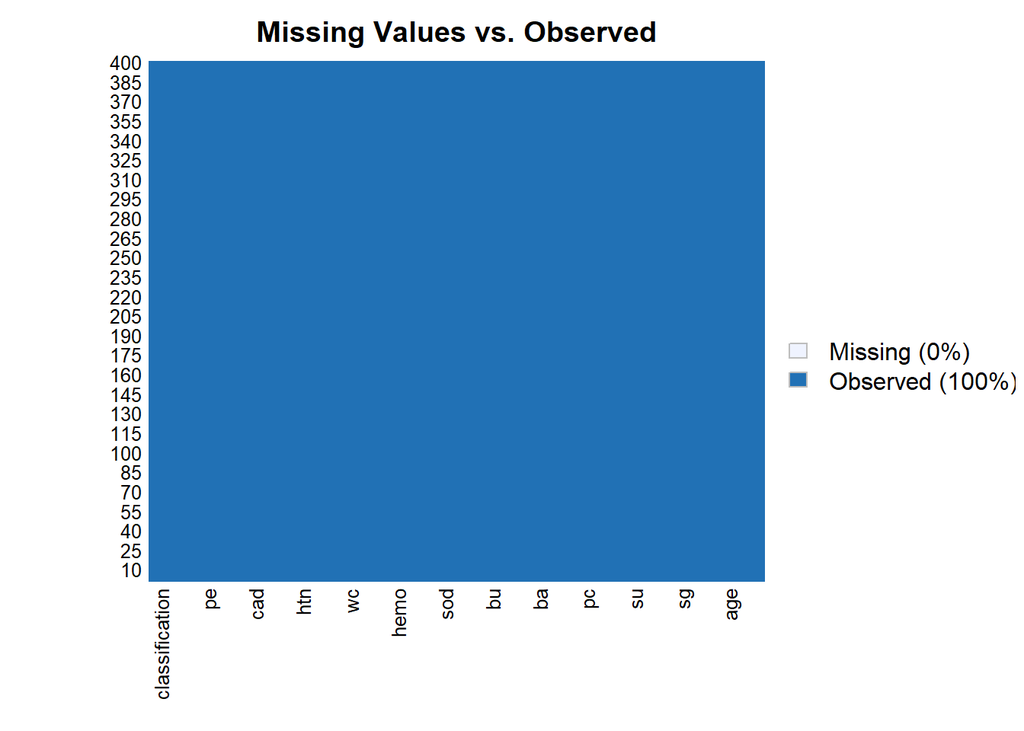

```r
library(Amelia)
missmap(data1, main = "Missing Values vs. Observed")
```

# Problem statement - Building a Multiple linear regression model on dependent variable blood pressure and independent variable age, blood Urea, Potassium, sodium, serum creatinine, hemoglobin, blood glucose random and esstimating their relationship

# Making a subset from the present main dataset

# Here we are selecting the variables according to the problem statement

```r
data2 = data1[,c("id", "age",  "bu", "pot", "sod", "sc", "hemo", "bgr", "bp")]
View(data2)
str(data2)
```

```
## 'data.frame':    400 obs. of  9 variables:
##  $ id  : int  0 1 2 3 4 5 6 7 8 9 ...
##  $ age : num  48 7 62 48 51 60 68 24 52 53 ...
##  $ bu  : num  36 18 53 56 26 25 54 31 60 107 ...
##  $ pot : num  4.63 4.63 4.63 2.5 4.63 ...
##  $ sod : num  138 138 138 111 138 ...
##  $ sc  : num  1.2 0.8 1.8 3.8 1.4 1.1 24 1.1 1.9 7.2 ...
##  $ hemo: num  15.4 11.3 9.6 11.2 11.6 12.2 12.4 12.4 10.8 9.5 ...
##  $ bgr : num  121 148 423 117 106 ...
##  $ bp  : num  80 50 80 70 80 ...
```

# Checking the null values in the new dataset created

```r
sum(is.na(data2))
```

```
## [1] 0
```

# Creating a correlation matrix for finding the relationship between all the data2 variables

```r
data2corr = cor(data2)
data2corr
```

```
##               id         age         bu         pot         sod          sc
## id    1.00000000 -0.18404301 -0.3009427 -0.08152412  0.32306392 -0.26469540
## age  -0.18404301  1.00000000  0.1875444  0.05014848 -0.08594884  0.12731604
## bu   -0.30094274  0.18754436  1.0000000  0.33697906 -0.30735965  0.58122247
## pot  -0.08152412  0.05014848  0.3369791  1.00000000  0.06744920  0.20534657
## sod   0.32306392 -0.08594884 -0.3073597  0.06744920  1.00000000 -0.62449138
## sc   -0.26469540  0.12731604  0.5812225  0.20534657 -0.62449138  1.00000000
## hemo  0.60950268 -0.17537998 -0.5406410 -0.10060555  0.33361403 -0.34207924
## bgr  -0.31993670  0.21441008  0.1274894  0.05669531 -0.15439345  0.08224197
## bp   -0.24373204  0.14800411  0.1839697  0.06664821 -0.10321973  0.14435870
##            hemo         bgr          bp
## id    0.6095027 -0.31993670 -0.24373204
## age  -0.1753800  0.21441008  0.14800411
## bu   -0.5406410  0.12748942  0.18396966
## pot  -0.1006056  0.05669531  0.06664821
## sod   0.3336140 -0.15439345 -0.10321973
## sc   -0.3420792  0.08224197  0.14435870
## hemo  1.0000000 -0.26914930 -0.27953539
## bgr  -0.2691493  1.00000000  0.14910045
## bp   -0.2795354  0.14910045  1.00000000
```

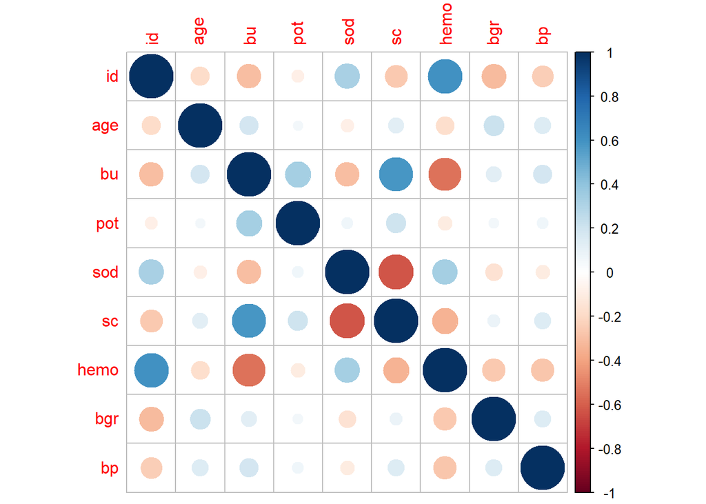

```r
library(corrplot)
# Plotting the correlation in graphical format
corrplot(data2corr)
```

# Analysing the variables of the model in the dataset

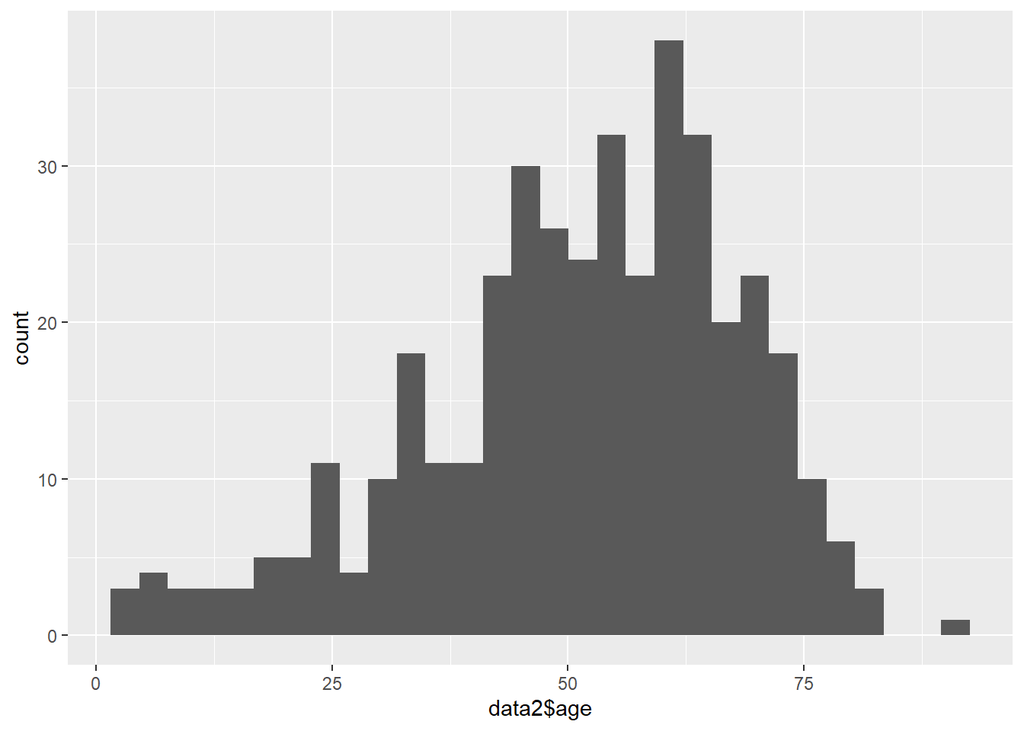

```r
library(ggplot2)
#Analysing age variable
ggplot(data2, aes(data2$age))+geom_histogram()
```

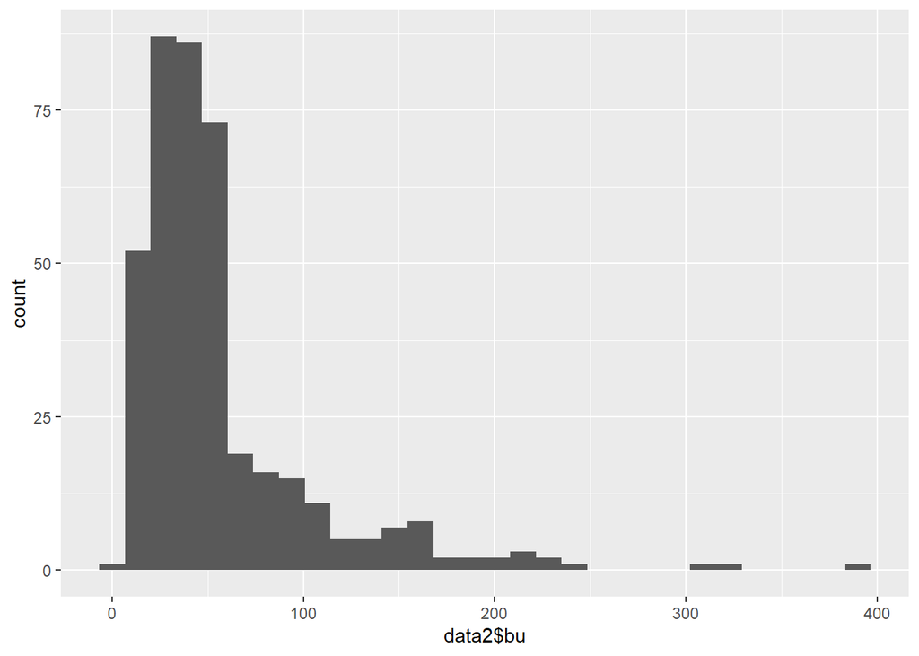

```r
#Analysing Blood Urea variable
ggplot(data2, aes(data2$bu))+geom_histogram()
```

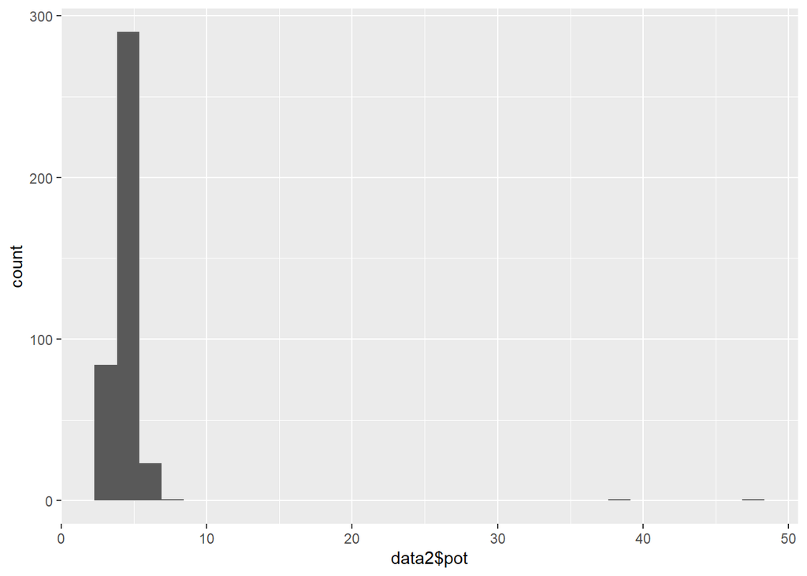

```r
# Analysing Potassium variable
ggplot(data2, aes(data2$pot))+geom_histogram()
```

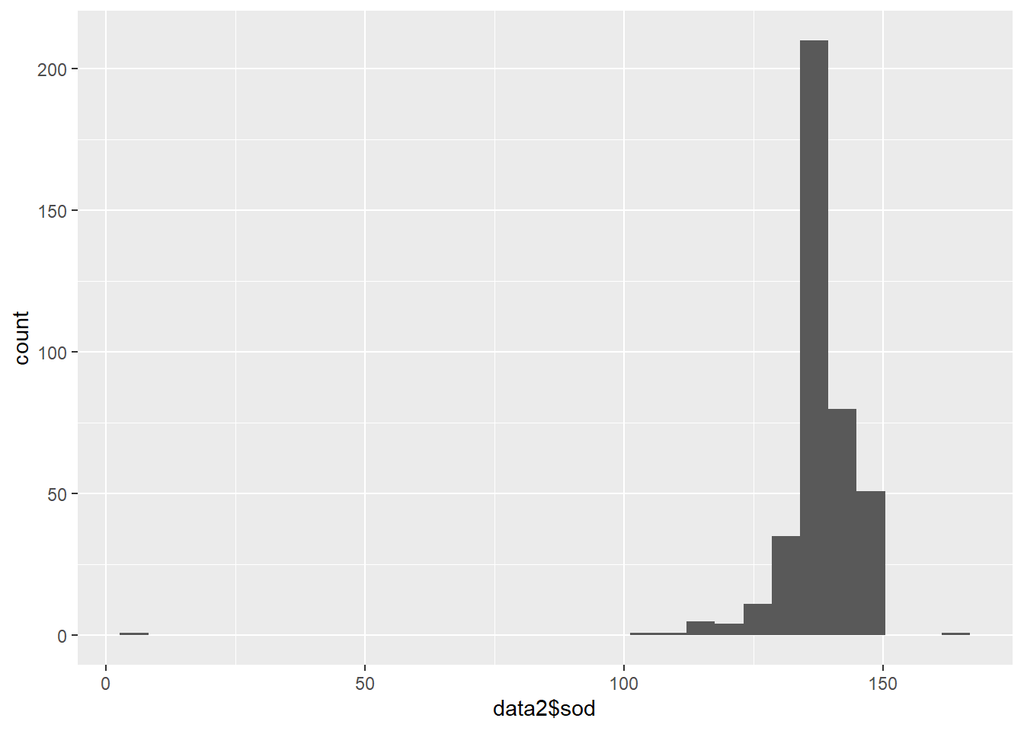

```r
# Analysing Sodium variable
ggplot(data2, aes(data2$sod))+geom_histogram()
```

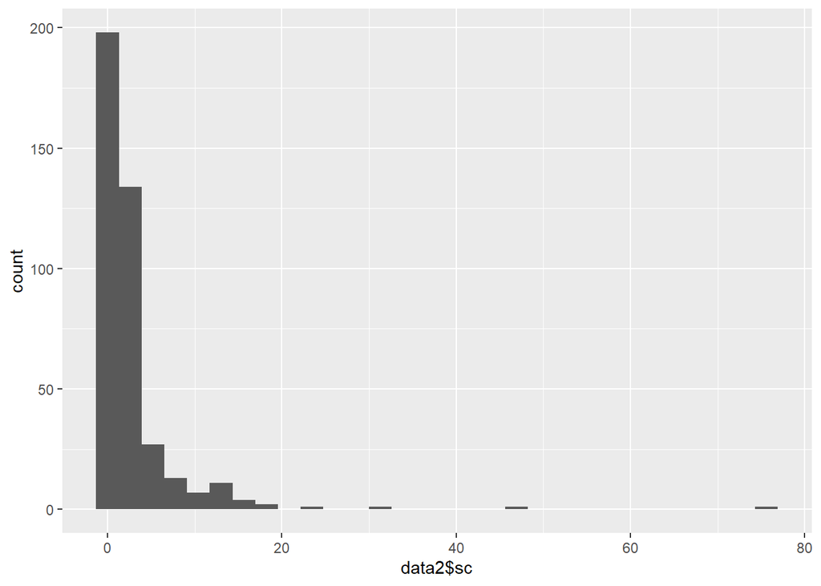

```r
# Analysing Serum Creatinine variable
ggplot(data2, aes(data2$sc))+geom_histogram()
```

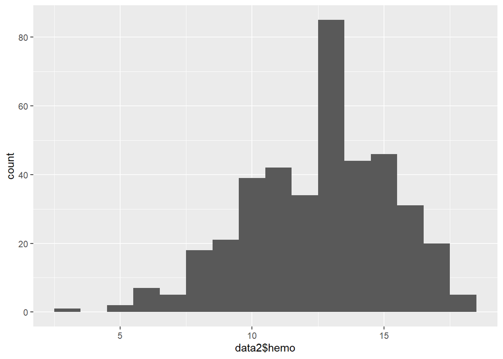

```r
#Analysing Hemoglobin variable
ggplot(data2, aes(data2$hemo))+geom_histogram(binwidth = 1)
```

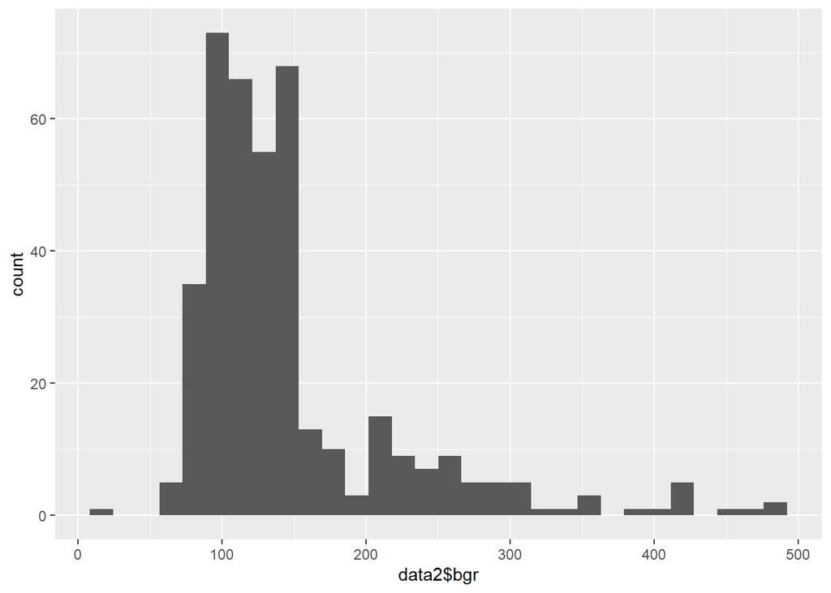

```r
# Analysing Blood glucose random variable
ggplot(data2, aes(data2$bgr))+geom_histogram()
```

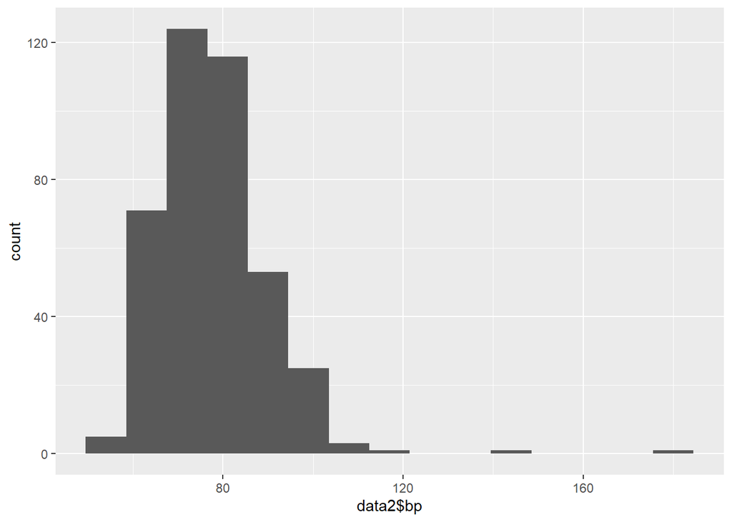

```r
#Analysing Blood pressure variable
ggplot(data2, aes(data2$bp))+geom_histogram(binwidth = 9)
```

# Performing Multiple linear regression on the problem statement by considering Blood pressure as dependent variable and age, blood Urea, Potassium, sodium, serum creatinine, hemoglobin, blood glucose random as independent variables

# y = bo + b1x1 + b2x2 + b3x3 + b4x4 + b5x5 + b6x6 + b7x7

# Null Hypothesis = H0 = b0 = b1 = b2 = b3 = b4 = b5 = b6 = b7 = 0

# Alternate Hypothesis = H1 = Atleast one is not equal to zero

# Splitting the data using caTools library

```r
library(caTools)
set.seed(100)
split1 = sample.split(data2$id, SplitRatio = 0.7)
split1
```

[output not shown]

[output cut: 19 more lines]

```r
summary(split1)
```

```
##    Mode   FALSE    TRUE
## logical     120     280
```

#Subsetting the dataset

```r
datatrain = subset(data2, split1 == TRUE)
datatest = subset(data2, split1 == FALSE)

dim(datatrain)
```

```
## [1] 280   9
```

```r
dim(datatest)
```

```
## [1] 120   9
```

#Developing a linear regression model for the above dependent variable blood pressure # Ho = b0 = b1 = b2 = b3 = b4 = b5 = b6 = b7 = 0 # H1 = Atleast one is not equal to zero

# As p value < 0.05 we reject null hypothesis and accept alternate Hypothesis, leading the model is useful as there is a relationship between independent and dependent variables, we can also see that adjusted R^2 is 0.0784.

# We can also observe in relationship between independent and dependent variables individually. We can observe that Hemoglobin independent variable is not satisfying the null hypothesis but all the other variables are satisfying the null hypothesis.

```r
reg1 = lm(datatrain$bp~
            datatrain$age+
            datatrain$bu+
            datatrain$pot+
            datatrain$sod+
            datatrain$sc+
            datatrain$hemo+
            datatrain$bgr, data = datatrain)

summary(reg1)
```

```
##
## Call:
## lm(formula = datatrain$bp ~ datatrain$age + datatrain$bu + datatrain$pot +
##     datatrain$sod + datatrain$sc + datatrain$hemo + datatrain$bgr,
##     data = datatrain)
##
## Residuals:
##     Min      1Q  Median      3Q     Max
## -29.087  -9.860   0.096   7.695  55.651
##
## Coefficients:
##                  Estimate Std. Error t value Pr(>|t|)
## (Intercept)    77.0604058 17.6649033   4.362 1.83e-05 ***
## datatrain$age   0.0625341  0.0438914   1.425 0.155377
## datatrain$bu    0.0013432  0.0224166   0.060 0.952265
## datatrain$pot   0.1512486  0.2447118   0.618 0.537048
## datatrain$sod   0.0817220  0.1305067   0.626 0.531715
## datatrain$sc    0.0649486  0.2122933   0.306 0.759886
## datatrain$hemo -1.3169371  0.3524880  -3.736 0.000228 ***
## datatrain$bgr   0.0007829  0.0098386   0.080 0.936631
## ---
## Signif. codes:  0 '***' 0.001 '**' 0.01 '*' 0.05 '.' 0.1 ' ' 1
##
## Residual standard error: 12.06 on 272 degrees of freedom
## Multiple R-squared:  0.1015, Adjusted R-squared:  0.0784
## F-statistic: 4.391 on 7 and 272 DF,  p-value: 0.0001232
```

# The below plot shows the visual implementation of multiple linear regression model

# The below plot is also used to find the Outliers

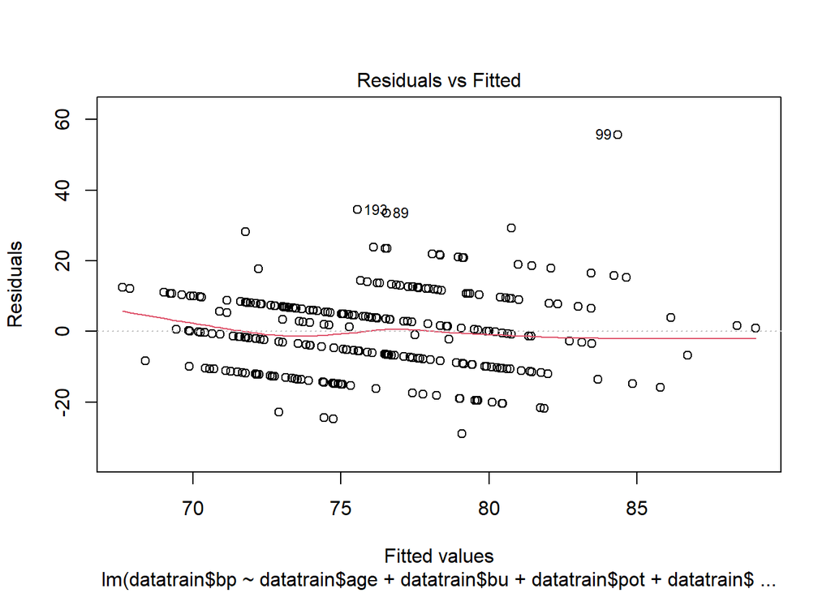

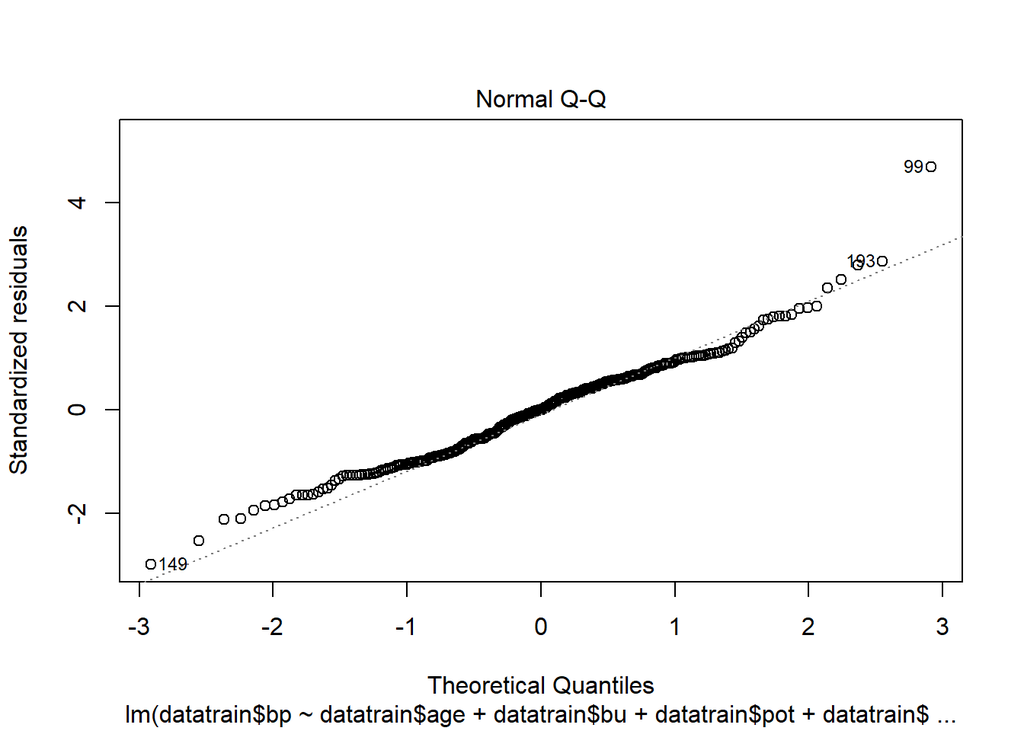

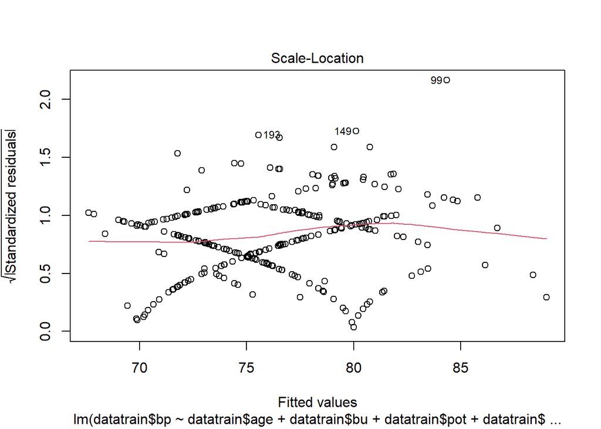

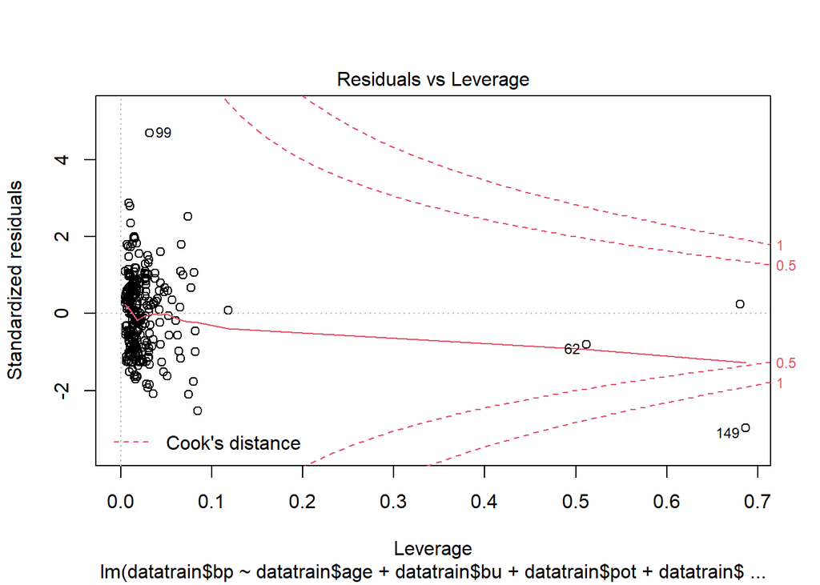

```r
plot(reg1)
```

```r
library(car)
outlierTest(reg1)
```

```
##    rstudent unadjusted p-value Bonferroni p
## 99 4.884571         1.7747e-06   0.00049691
```

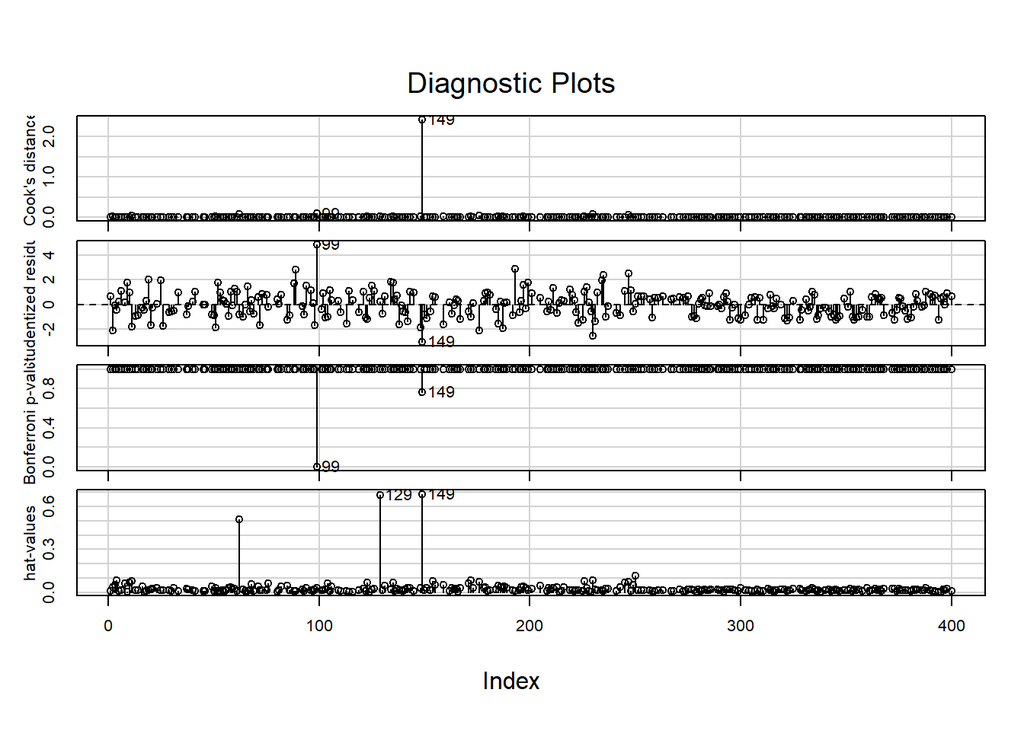

```r
influenceIndexPlot(reg1)
```